# Capstone NLP Milestone Report

Jason B.

9/11/2018

## Summary

The goal of this project is create a simple predictive text algorithm in R and deploy it using a Shiny app hosted on on a server with a 1Gb capacity. The text that will be used to create the algorithm is derived from a collection of text from Twitter, blogs, and news articles from the United States written in English. This document summarizes the data, my efforts so far in understanding patterns in those data, and my plans for building and deploying the algorithm.

## Exploration of the data

After an initial exploration of various text analysis packages in R, I chose to rely heavily on “quanteda” because it seems to be the most mature in terms of development, is relatively fast, and has thorough documenation. http://docs.quanteda.io/articles/pkgdown/comparison.html

## Analyzing the data files

The starting text for this project is downloaded from https://d396qusza40orc.cloudfront.net/dsscapstone/dataset/Coursera-SwiftKey.zip. The english text is found in the folder “final/en_US”. As you can see from this table, the files are quite large. After some initial testing, I found that I was able to load and store the entire dataset on my personal computer. The data.table::fread and readr::read_lines package were faster and more flexible than readtext, but it was more complicated to convert the resulting data types into a data frame compatible with quanteda::corpus. In the end it was more effort and almost as much system time to use fread or readr rather than readtext; so I chose to go with readtext for simplicity and code readability.

| File name | File Size (Mb) | number of lines |
| --- | --- | --- |
| en_US.blogs.txt | 200.4 | 899288 |
| en_US.news.txt | 196.3 | 1010242 |
| en_US.twitter.txt | 159.4 | 2360148 |

```
## Corpus consisting of 3 documents:
##
##               Text  Types   Tokens Sentences Language     Source
##    en_US.blogs.txt 482432 42840140   2072941       en   US.blogs
##     en_US.news.txt 431664 39918314   1867522       en    US.news
##  en_US.twitter.txt 566951 36719658   2588551       en US.twitter
##
## Source: /Users/jason/Coursera_datascience_specialization/10 Datascience Capstone/* on x86_64 by jason
## Created: Tue Sep 11 13:31:46 2018
## Notes:
```

## Top ngram features

I calculated a document feature matrix for unigrams, bigrams and trigrams. The following table shows the number of unique ngrams for each type.

| Type | # of ngrams | # of ngrams occuring 5 or more times |
| --- | --- | --- |
| unigrams | 823153 | 164496 |
| bigrams | 15760673 | 1597574 |
| trigrams | 51346690 | 2002844 |

I then plotted histograms of the top 20 ngrams for each type broken down by the source text. As expected, the most frequent words are stopwords. Apparently twitter users are more thankful than bloggers or news journalists.

## Top Unigrams

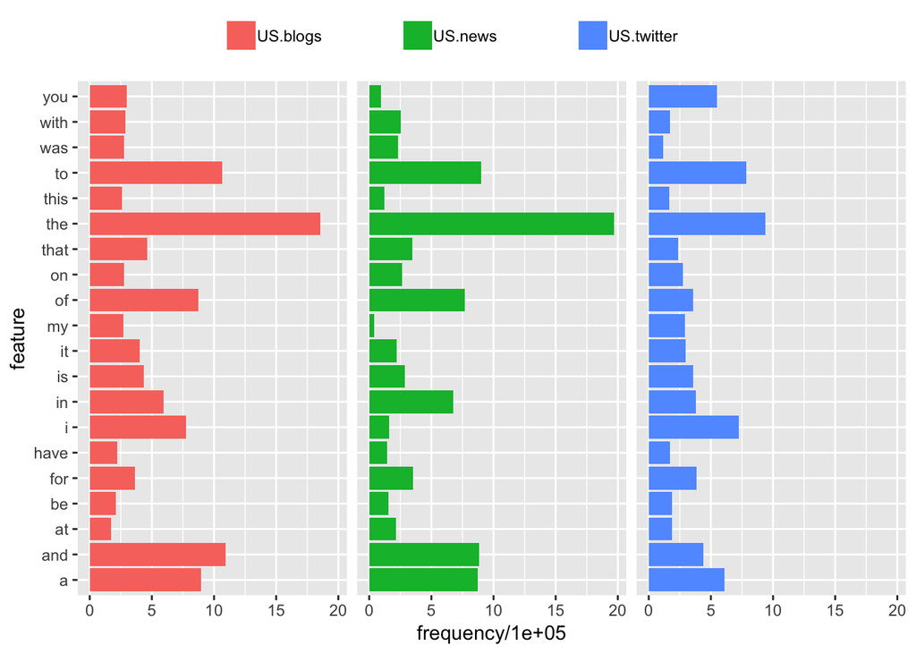

## Top Bigrams

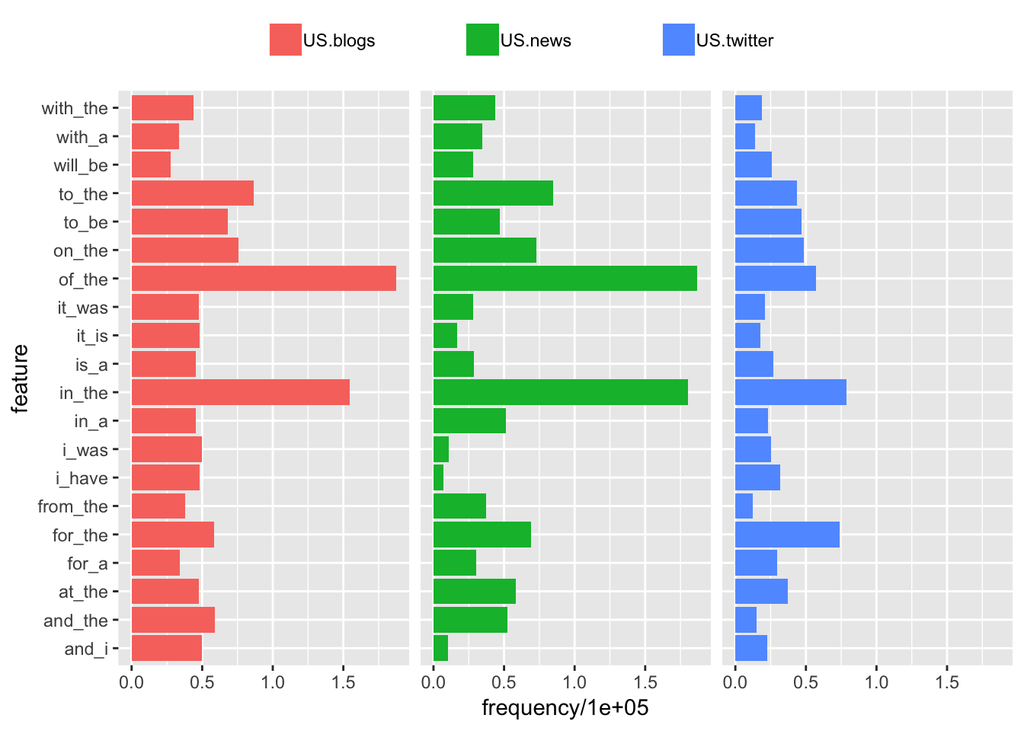

## Top Trigrams

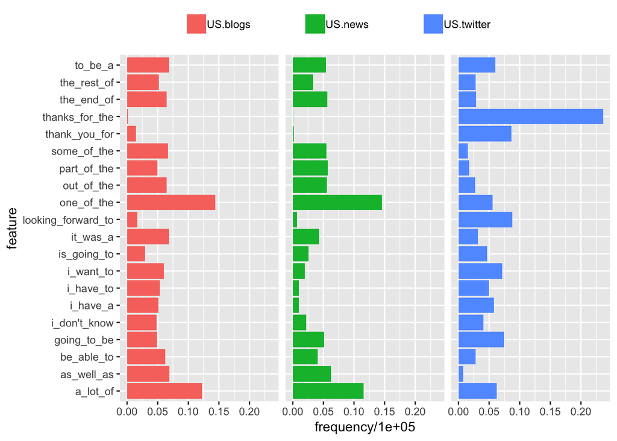

## Appendix

```r
library(stringr); library(quanteda); library(readtext)
library(doParallel); library(parallel)
library(ggplot2); library(data.table)


#assumes the current working directory is the top level of the zip file
filepath <- "./final/en_US/"
filenames <- dir(filepath)
numfiles <- length(filenames)
df <- data.frame(
        filepath =  rep(filepath, numfiles),
        filenames,
        filesize = double(length = numfiles),
        filelength = integer(length = numfiles)
        )

#calculates file size and length and populated data frame
for (i in 1:numfiles){
        FILE <- paste0(df$filepath[i], df$filenames[i])
        df$filesize[i] <- round(file.size(FILE)/2^20, 1)
        df$filelength[i] <- as.integer(
                str_split(
                        system(
                        sprintf("wc -l %s", FILE), intern = T), "\\s+")[[1]][2])
}

cl <- makeCluster((detectCores()-1), type = "FORK")
registerDoParallel(cl)

en_US.corpus <- corpus(readtext("final/en_US/", docvarsfrom = "filenames", docvarnames = c("Language", "Source"))) #~1min

(summary.en_US.corpus <- summary(en_US.corpus)) #~6.5min

gc()

en_US.dfm <- lapply(1:3, function(n) {
        dfm(
        en_US.corpus,
        tolower = T,
        remove_punct = T,
        remove_numbers = T,
        remove_twitter = T,
        ngrams = n
        )
}) #~23min



en_US.dfm.trim <- lapply(en_US.dfm, function(x) {
         dfm_trim(x, min_termfreq = 5)
 }) #reduces dfm size from 6Gb to 386Mb, ~1min


rm(en_US.dfm)

top_features <- lapply(en_US.dfm.trim, function(x) topfeatures(x, 20))
ngrams_dt <- lapply(1:3, function(n) data.table(textstat_frequency(en_US.dfm.trim[[n]], groups = "Source")))#~1min
names(ngrams_dt) <- c("Unigrams", "Bigrams", "Trigrams")

makeplots <- function(x){
                dt <- ngrams_dt[[x]][feature %in% names(top_features[[x]]), ]

                ggplot(dt, aes(x=feature, frequency/100000, fill = group))+
                        geom_bar(stat="identity")+
                        coord_flip()+
                        facet_grid(~group)+
                        theme(strip.text.x = element_blank(),
                              legend.position = "top",
                              legend.direction = "horizontal",
                              legend.title = element_blank(),
                              legend.text = element_text(margin = margin(r = 5, unit = "char")))

}

plots <- lapply(1:3, makeplots)#~1min

plots[[1]]
plots[[2]]
plots[[3]]
```